# Documentación de texto

Jesus Mudarra Luján

2022-09-14

# Título 1

## Título 2

### Título 3

Esto sería una nueva línea de texto. Fijaros que para que separe los párrafos necesitamos siempre al menos un doble intro.

Para colocar cursiva podemos usar un asterisco: *esto sería un texto en cursiva* o bien usar una sola barra baja *esto tambien es crusiva*.

Para colocar negrita podemos usar un doble asterisco: **esto es negrita** o bien una doble barra baja **esto también es negrita**.

Los superíndices van con el *sombrerito*: este curso vale por mi nota<sup>2</sup>. Juan Gabriel<sup>profeonline</sup>…

Para tachar una palabra usamos una doble tilde Las matemáticas son un rollo.

Para conocer más sobre los cursos de Juan Gabriel, podemos visitar su perfil de [perfil de Udemy](https://udemy.com/u/juangabriel2)

endash: – Y entonces Juan Gabriel digo: …

emdash: … — como Juan Gabriel quería explicar.

elipsis: …

ecuaciones en línea: $S = \pi\cdot r^2$

imagen:

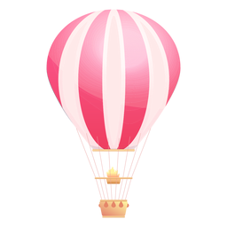

Aquí empezamos otra cosa

> Esto es una cita en bloque

### Listas no ordenadas

- Ítem primero
- Ítem segundo
- Ítem tercero
  - Sub ítem 3.1
  - Sub ítem 3.2
- Ítem cuarto

### Listas ordenadas

1. Primer ítem
2. Segundo ítem
   - Sub ítem de 2
   - Nuevo sub ítem
3. Tercer ítem
4. Cuarto ítem
5. Último ítem

   | Alumno | Nota |
   | --- | --- |
   | Juan Gabriel | 3.5 |
   | Ricardo | 5.6 |
   | María | 7.3 |
   | Antonio | 9.5 |